# Practical Machine Learning

Joan Braithwaite

March 30, 2016

Background

Using devices such as Jawbone Up, Nike FuelBand, and Fitbit it is now possible to collect a large amount of data about personal activity relatively inexpensively. These type of devices are part of the quantified self movement - a group of enthusiasts who take measurements about themselves regularly to improve their health, to find patterns in their behavior, or because they are tech geeks. One thing that people regularly do is quantify how much of a particular activity they do, but they rarely quantify how well they do it.

The goal of this project, is to predict the manner in which they did the exercise using data from accelerometers on the belt, forearm, arm, and dumbell of 6 participants. Participants were asked to perform barbell lifts correctly and incorrectly in 5 different ways. More information is available from the website here: http://groupware.les.inf.puc-rio.br/har (see the section on the Weight Lifting Exercise Dataset).

Data

The training data for this project are available here:

https://d396qusza40orc.cloudfront.net/predmachlearn/pml-training.csv

The test data are available here:

https://d396qusza40orc.cloudfront.net/predmachlearn/pml-testing.csv

The data for this project come from this source: http://groupware.les.inf.puc-rio.br/har. If you use the document you create for this class for any purpose please cite them as they have been very generous in allowing their data to be used for this kind of assignment.

```r
rm(list = ls())
if (!file.exists("pml-training.csv")) {
  download.file("http://d396qusza40orc.cloudfront.net/predmachlearn/pml-training.csv", destfile = "pml-training.csv")
}
if (!file.exists("pml-testing.csv")) {
  download.file("http://d396qusza40orc.cloudfront.net/predmachlearn/pml-testing.csv", destfile = "pml-testing.csv")
}
Test.data <- read.csv("pml-testing.csv", sep = ",", na.strings = c("", "NA"))
Train.data <- read.csv("pml-training.csv", sep = ",", na.strings = c("", "NA"))
```

# Prepare the data

```r
# Remove columns with NAs.
features <- names(Test.data[,colSums(is.na(Test.data)) == 0])[8:59]

# Only use features used in Test.data cases.
Train.data <- Train.data[,c(features,"classe")]
Test.data <- Test.data[,c(features,"problem_id")]
```

# Building & Identifying the best model

## The goal of this project is to predict the manner in which they did the exercise. So my process is to:

### 1) create a training and test set of data.

### 2) try a few different models to see which one would provide the most accurate prediction.

### 3) cross-validation was used on each model (using a separate set of data) to check for overfitting.

### 4) use the one with the highest accurary to predict the values from the test data to be submitted for the class as part of this project.

# Create training and test data to verify model

```r
library(caret)
set.seed(3433)

library(AppliedPredictiveModeling)

inTrain = createDataPartition(Train.data$classe, p = 0.75, list = F)
training = Train.data[inTrain,]
testing = Train.data[-inTrain,]
```

# Prediction with Decision Trees

```r
library(rpart)
library(rattle)
```

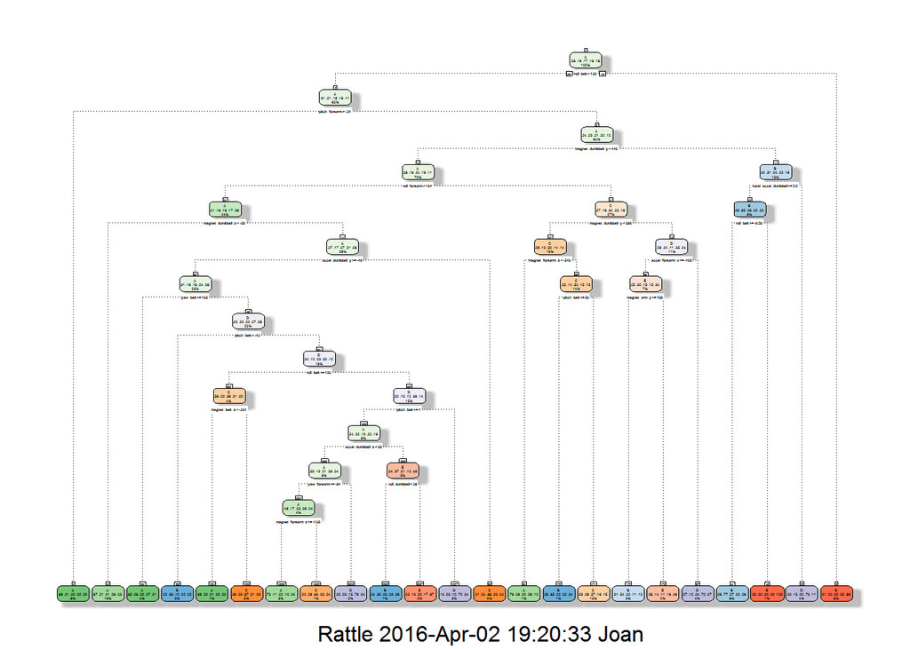

```r
set.seed(12345)

modFitDS <- rpart(classe ~ ., data=training, method="class")
fancyRpartPlot(modFitDS)
```

```r
predictionsDS <- predict(modFitDS, testing, type = "class")
cmtree <- confusionMatrix(predictionsDS, testing$classe)
cmtree
```

```
## Confusion Matrix and Statistics
##
##           Reference
## Prediction    A    B    C    D    E
##          A 1267  219   10   86   38
##          B   25  530   85   28   71
##          C   38   94  684  139  107
##          D   42   64   54  491   42
##          E   23   42   22   60  643
##
## Overall Statistics
##
##                Accuracy : 0.7372
##                  95% CI : (0.7246, 0.7494)
##     No Information Rate : 0.2845
##     P-Value [Acc > NIR] : < 2.2e-16
##
##                   Kappa : 0.6657
##  Mcnemar's Test P-Value : < 2.2e-16
##
## Statistics by Class:
##
##                      Class: A Class: B Class: C Class: D Class: E
## Sensitivity            0.9082   0.5585   0.8000   0.6107   0.7137
## Specificity            0.8994   0.9472   0.9066   0.9507   0.9633
## Pos Pred Value         0.7821   0.7172   0.6441   0.7085   0.8139
## Neg Pred Value         0.9610   0.8994   0.9555   0.9257   0.9373
## Prevalence             0.2845   0.1935   0.1743   0.1639   0.1837
## Detection Rate         0.2584   0.1081   0.1395   0.1001   0.1311
## Detection Prevalence   0.3303   0.1507   0.2166   0.1413   0.1611
## Balanced Accuracy      0.9038   0.7528   0.8533   0.7807   0.8385
```